# Reproducible Research: Peer Assessment 1

## Loading and preprocessing the data

We can load the given data using read.csv()

```r
library("knitr")
library("dplyr")
doc<- read.csv("activity.csv")
```

## What is total number of steps taken per day?

By analyzing the total no. of steps travelled each day we can see that the subject travels around 9000-13000 steps (as it has the highest frequency)

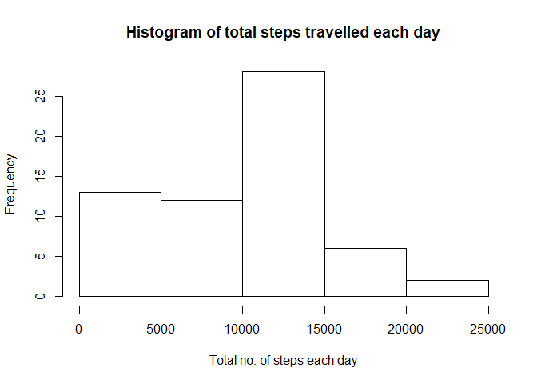

```r
doc_sum<- group_by(doc,date)%>%summarize(sum= sum(steps,na.rm = TRUE))
doc_sum$sum[which(is.na(doc_sum$sum))] <- 0
hist(doc_sum$sum,
     xlab = "Total no. of steps each day",
     ylab = "Frequency",
     main ="Histogram of total steps travelled each day")
```

The mean and median for total no. of steps each day is :-

```r
summary(doc_sum$sum)[3:4]
```

```
##   Median     Mean
## 10395.00  9354.23
```

## What is the average daily activity pattern?

Lets see the plot of average steps taken vs time:- (at x axis 345 means 3:45am)

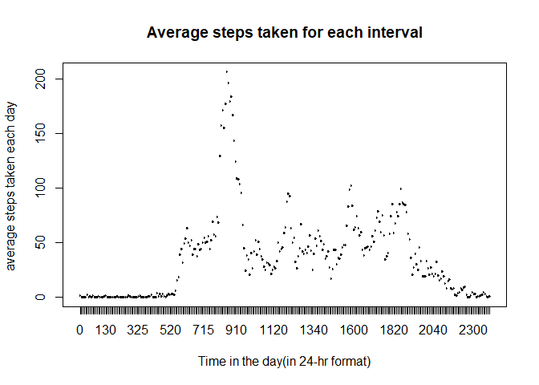

```r
doc_avg<- doc%>%group_by(interval=factor(doc$interval))%>%summarize(average=mean(steps,na.rm = TRUE))
plot(doc_avg$interval,
     doc_avg$average,
     type="l",
     xlab="Time in the day(in 24-hr format)",
     ylab="average steps taken each day ")
title("Average steps taken for each interval")
```

As we can see the most steps travelled is between 8:00am to 9:10am

```r
doc_avg[which(doc_avg$average==max(doc_avg$average)),1]
```

```
## # A tibble: 1 x 1
##   interval
##   <fct>
## 1 835
```

## Imputing missing values

We can remove the missing values present for steps calculated for specific days :-  
1.**Mean Imputation**:- the interval where NA is present is changed to the mean of the 5-minute interval for every non-NA day.  
2. **Median Imputation:-**the interval where NA is present is changed to the median of the 5-minute interval for every non-NA day.

I have used mean strategy and added to doc_1:-

```r
doc_1<-doc
vec<-  which(is.na(doc_1$steps))
for(i in vec){
  interval<- doc_1$interval[i]
  doc_1$steps[i]<- doc_avg$average[which(doc_avg$interval==interval)]
}
which(is.na(doc_1$steps))
```

```
## integer(0)
```

Integer(0) proves that no NA values remain

This change can also be seen by an histogram used for total no. of steps travelled:-

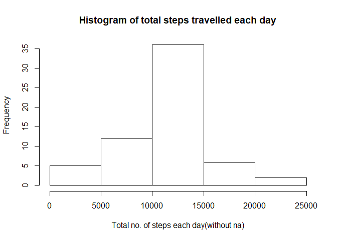

```r
doc_sum1<- group_by(doc_1,date)%>%summarize(sum= sum(steps))
hist(doc_sum1$sum,
     xlab = "Total no. of steps each day(without na)",
     ylab = "Frequency",
     main ="Histogram of total steps travelled each day")
```

## Are there differences in activity patterns between weekdays and weekends?

You can see at below graph that the subject traveles more on weekends than on weekdays.Also , as we can see in the graph that the subject has travelled more steps during time interval **12:00-6:00pm** on weekends than on weekdays  
You can divide the dates according to weekdays using *weekdays()*  
Now by summarizing the details for weekdays and weekends we panel-plot them as follows:-

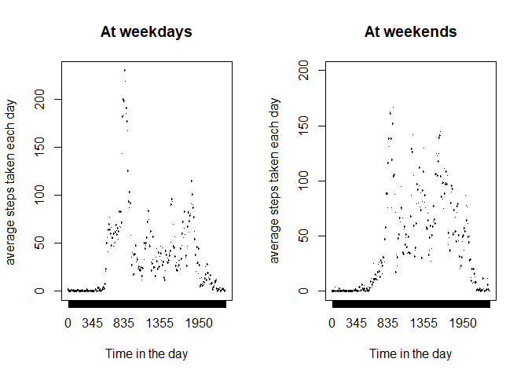

```r
time<- as.Date(doc_1$date)
days<- weekdays(time)
doc_new<- cbind(doc_1,days)
doc_weekday<- filter(doc_new,days!="Saturday" & days!="Sunday")
doc_weekends<- filter(doc_new,days=="Saturday" | days=="Sunday")

doc_avg_weekday<- doc_weekday%>%group_by(interval=factor(interval))%>%summarize(average=mean(steps))
doc_avg_weekend<- doc_weekends%>%group_by(interval=factor(interval))%>%summarize(average=mean(steps))
par(mfrow=c(1,2))
plot(doc_avg_weekday$interval,
     doc_avg_weekday$average,
     type="h",
     xlab="Time in the day",
     ylab="average steps taken each day ")
title("At weekdays")

plot(doc_avg_weekend$interval,
     doc_avg_weekend$average,
     type="l",
     xlab="Time in the day",
     ylab="average steps taken each day",
     ylim=c(0,200))

title("At weekends")
```